# Elastic Net Regression and Genetic Algorithm Feature Selection for Quantifying Instant Coffee Adulteration: Raw Spectra

Author

Derick Malavi

## Introduction

Coffee adulteration, such as blending premium Arabica with lower-cost Robusta, undermines quality and authenticity, posing significant challenges for consumers, producers, and regulators. High-dimensional spectroscopic data provides valuable insights for detecting such fraud, but the large number of variables necessitates effective feature selection techniques to isolate the most relevant wavelengths.

This study combines Recursive Feature Elimination (RFE) and Genetic Algorithm (GA) to identify the most critical spectral features for predicting coffee adulteration. These methods complement each other by ensuring the selection of non-redundant, high-impact features, which are crucial for optimizing model accuracy and interpretability.

This study employs Elastic Net regression, a robust technique that combines the strengths of elastic_net (L1 regularization) and Ridge (L2 regularization). Elastic Net balances feature selection and coefficient shrinkage, effectively addressing multicollinearity while retaining critical spectral features. This approach enables efficient modeling with high-dimensional data by reducing redundancy and improving prediction accuracy.

```r
# Load libraries
warning = FALSE
  suppressWarnings(suppressMessages({
  library(caret)
  library(GA)
  library(glmnet)
  library(viridis)
  library(Boruta)
  library(ggplot2)
  library(dplyr)
  library(readxl)
  library(readr)
  library(janitor)
  library(class)
  library(MLmetrics)
  library(MLeval)
  library(themis)
  library(ROSE)
  library(parallel)
  library(doParallel)
  library(foreach)
  library(pheatmap)
  library(mdatools)
  library(nnet)
  library(DMwR)
  library(e1071)
  library(knitr)
  library(pROC)
  library(gridExtra)
  library(FactoMineR)
  library(doSNOW)
  library(MASS)
  library(factoextra)
  library(kernlab)}))
```

## Prepare Data

```r
# Load data: raw spectra

hsi_raw <- read.csv("instant_coffee_raw.csv")

# Ensure we have the same number of dimensions and the range of our columns/covariates
dim(hsi_raw)
```

```
[1] 1476  229
```

```r
# Check a few column names
col_check <- colnames(hsi_raw[,c(1:6)])
col_check
```

```
[1] "sample_name"  "binary_class" "three_class"  "cal_val"      "perc_adulter"
[6] "X935.609985"
```

```r
# our response variable (adulteration percentage) is column 4
# The spectral values start from column # 6 -------> 229

# Convert the adulteration percentage to numeric for compatibility with ML
hsi_raw$perc_adulter <- as.numeric(hsi_raw$perc_adulter)
```

## Get the X and y variables

```r
X <- hsi_raw[,c(6:229)]
y <- hsi_raw[,5]

class(y) #Ensure y (target variable) is a numeric for regression
```

```
[1] "numeric"
```

## Visualize X

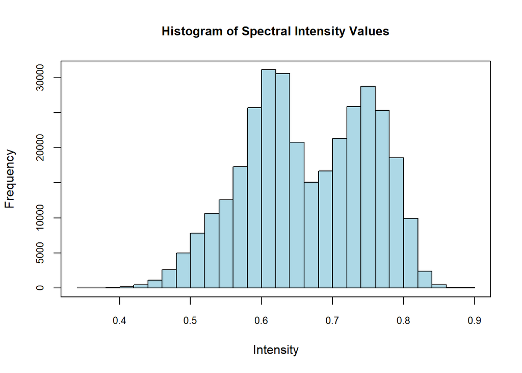

```r
hist(as.matrix(X), col = 'lightblue', cex.main = 1.0, cex.axis = 0.8,cex.lab = 1.0,
     main = 'Histogram of Spectral Intensity Values', xlab = 'Intensity'); box()
```

## Split the Data (Train_Test Split)

- We want to select features based on training data only to avoid any data leakage that could inflate model performance and make the model less generalizable to unseen data.

```r
# Subset samples for cross-validation and external validation (70/30)
# Record 1 under cal_val variable is for calibration while 2 will be for testing the model

sample<-hsi_raw$cal_val == 1

# Split to train and test sets
X_train <- X[sample,]
X_test <- X[!sample,]
y_train <-y[sample]
y_test <- y[!sample]

# Check length of the subsets for training and validation
dim(X_train)
```

```
[1] 1065  224
```

```r
dim(X_test)
```

```
[1] 411 224
```

```r
length(y_train)
```

```
[1] 1065
```

```r
length(y_test)
```

```
[1] 411
```

```r
# Merge the test and train data
train_data <- data.frame(X_train, y_train)
test_data <- data.frame(X_test, y_test)
```

## Define the Fitness Function for GA

- This function evaluates subsets of features selected by GA using RFE with a Random Forest (RF) model.

```r
# Fitness Function for RMSE
fitness_ga_rfe <- function(subset) {
  # Identify selected features based on the binary subset
  selected_features <- which(subset == 1)

  # Penalize empty subsets to avoid errors
  if (length(selected_features) == 0) return(Inf)

  # Subset the training feature matrix to selected features
  X_selected <- X_train[, selected_features]

  # Define control for RFE
  control <- rfeControl(functions = rfFuncs,
                        method = "cv",
                        number = 10)

  # Apply RFE to the selected subset of features
  rfe_result <- rfe(X_selected, y_train, rfeControl = control, metric = "RMSE")

  # Return the RMSE as the fitness score (lower is better)
  return(min(rfe_result$results$RMSE))
}
```

```r
# Set seed for reproducibility
set.seed(123)

num_features <- ncol(X_train) # Number of features
dataset_name <- "raw"   # Set the dataset name dynamically

# Define paths for the execution flag and GA result
flag_file <- paste0("ga_executed_flag_", dataset_name, ".RData")
result_file <- paste0("ga_result_", dataset_name, ".RData")

# Check if the result file exists
if (!file.exists(result_file)) {
  message("No result file found. Running the Genetic Algorithm (GA).")

  # Register cluster for caret to train the models in parallel
  cl <- makeCluster(6, type = "SOCK")
  suppressWarnings(suppressMessages(registerDoSNOW(cl)))

  # Register start time
  start_time <- Sys.time()

  # Run the Genetic Algorithm
  ga_result <- ga(
    type = "binary",
    fitness = fitness_ga_rfe,
    nBits = num_features,             # Number of features
    popSize = 20,                     # Population size
    maxiter = 50,                     # Maximum iterations
    run = 10,                         # Convergence stopping criterion
    names = colnames(train_data[, -ncol(train_data)]),  # Feature names
    pcrossover = 0.8,                 # Probability of crossover
    pmutation = 0.1,                  # Probability of mutation
    parallel = TRUE,                  # Enable parallel processing
    monitor = gaMonitor,              # Track progress
    seed = 123                        # Reproducibility
  )

  # Stop the cluster
  stopCluster(cl)

  # Register end time
  end_time <- Sys.time()
  print(paste('Time to run the GA model:', end_time - start_time))

  # Save the GA result and execution flag
  ga_executed <- TRUE
  save(ga_executed, ga_result, file = result_file)  # Save both flag and results

  message("GA execution completed and results saved.")

} else {
  # Load previously saved results
  message("Result file found. Loading saved GA results.")
  load(result_file)
  message(paste("GA already executed for dataset:", dataset_name))
}
```

```
Result file found. Loading saved GA results.
```

```
GA already executed for dataset: raw
```

## Visualization Plot

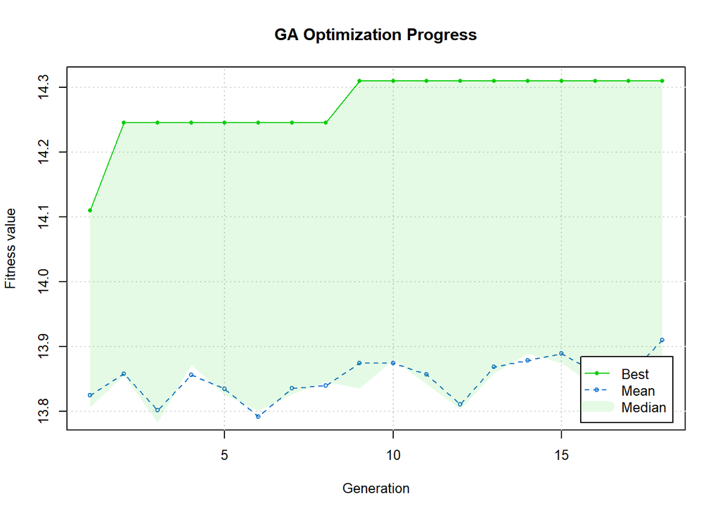

```r
par (cex = 0.8)
plot(ga_result, main = "GA Optimization Progress")
```

```r
par(cex = 1)
```

## Analyze GA results

```r
summary(ga_result)
```

```
── Genetic Algorithm ───────────────────

GA settings:
Type                  =  binary
Population size       =  20
Number of generations =  50
Elitism               =  1
Crossover probability =  0.8
Mutation probability  =  0.1

GA results:
Iterations             = 18
Fitness function value = 14.31026
Solution =
     X935.609985 X939.059998 X942.52002 X945.97998 X949.429993 X952.890015
[1,]           1           0          1          1           0           1
     X956.349976 X959.809998 X963.27002 X966.72998  ...  X1716.650024
[1,]           0           1          0          0                  1
     X1720.22998
[1,]           0
```

## Post-Selection

```r
# Get the best feature subset
best_features <- which(ga_result@solution == 1)
selected_feature_names <- colnames(train_data)[best_features]
print(selected_feature_names)
```

```
  [1] "X935.609985"  "X942.52002"   "X945.97998"   "X952.890015"  "X959.809998"
  [6] "X970.190002"  "X977.109985"  "X987.51001"   "X997.900024"  "X1004.830017"
 [11] "X1008.299988" "X1015.23999"  "X1022.179993" "X1025.650024" "X1029.119995"
 [16] "X1032.589966" "X1036.060059" "X1039.530029" "X1043"        "X1053.430054"
 [21] "X1063.849976" "X1067.329956" "X1084.719971" "X1091.680054" "X1095.170044"
 [26] "X1098.650024" "X1112.579956" "X1116.069946" "X1119.550049" "X1126.52002"
 [31] "X1130.01001"  "X1147.449951" "X1154.430054" "X1161.420044" "X1171.900024"
 [36] "X1175.390015" "X1178.890015" "X1182.380005" "X1185.880005" "X1189.369995"
 [41] "X1192.869995" "X1196.369995" "X1203.369995" "X1206.869995" "X1231.380005"
 [46] "X1234.880005" "X1252.410034" "X1259.420044" "X1262.930054" "X1269.949951"
 [51] "X1273.459961" "X1280.47998"  "X1287.51001"  "X1291.02002"  "X1298.050049"
 [56] "X1301.560059" "X1308.589966" "X1312.109985" "X1315.619995" "X1326.180054"
 [61] "X1329.699951" "X1333.219971" "X1336.73999"  "X1347.300049" "X1350.819946"
 [66] "X1357.869995" "X1364.920044" "X1368.439941" "X1371.969971" "X1375.5"
 [71] "X1386.079956" "X1400.199951" "X1407.26001"  "X1414.319946" "X1417.859985"
 [76] "X1421.390015" "X1428.459961" "X1431.98999"  "X1439.069946" "X1442.599976"
 [81] "X1449.680054" "X1453.219971" "X1460.300049" "X1467.380005" "X1470.920044"
 [86] "X1478.01001"  "X1481.550049" "X1488.640015" "X1492.180054" "X1495.72998"
 [91] "X1499.27002"  "X1502.819946" "X1509.910034" "X1513.459961" "X1527.660034"
 [96] "X1545.420044" "X1548.97998"  "X1556.089966" "X1566.75"     "X1570.310059"
[101] "X1573.869995" "X1580.98999"  "X1605.920044" "X1609.47998"  "X1616.609985"
[106] "X1627.310059" "X1630.869995" "X1645.150024" "X1652.290039" "X1655.859985"
[111] "X1673.719971" "X1684.439941" "X1695.170044" "X1698.75"     "X1716.650024"
```

```r
print(paste('The number of selected variables are', length(selected_feature_names)))
```

```
[1] "The number of selected variables are 115"
```

```r
n_selected <- as.numeric(length(selected_feature_names))
```

## Create a Data frame with the Selected Features

```r
# Subset the training and test data using the selected features
X_train_selected <- X_train[, selected_feature_names]
X_test_selected <- X_test[, selected_feature_names]

# Keep y_train and y_test as-is
y_train_selected <- y_train
y_test_selected <- y_test

#Merge data_frame
train_merged <- cbind(y_train = y_train_selected, X_train_selected)
test_merged <- cbind(y_test = y_test_selected, X_test_selected)

dim(train_merged)
```

```
[1] 1065  116
```

```r
dim(test_merged)
```

```
[1] 411 116
```

## Check correlations by HeatMaps

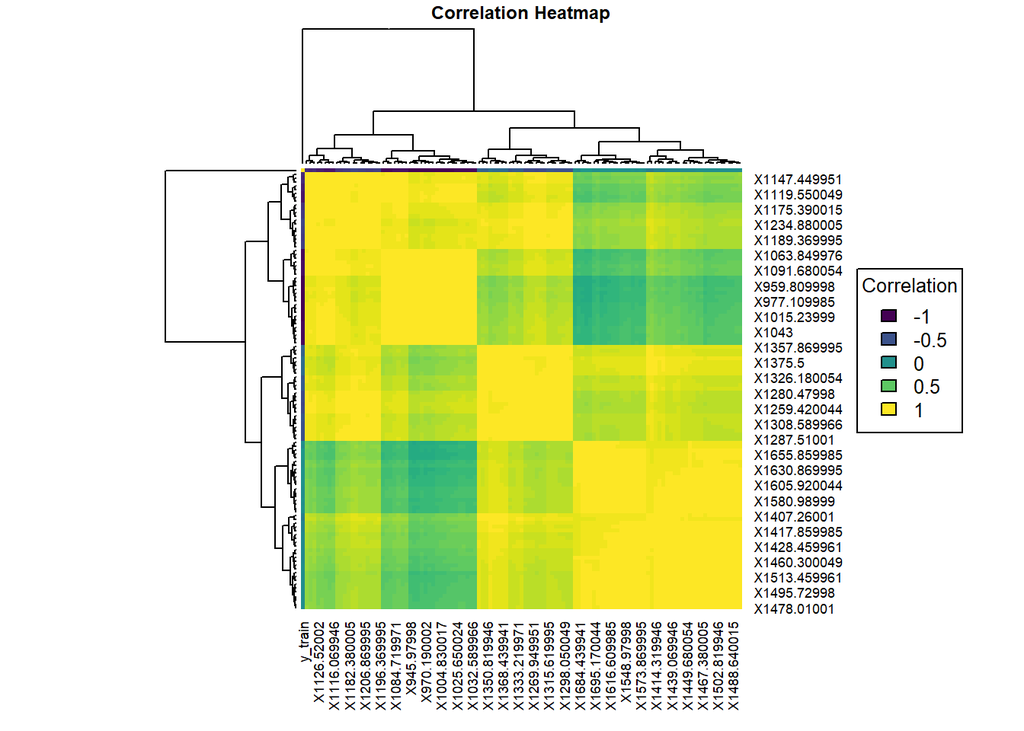

```r
n_features <- length(n_selected)

#Calculate correlations
corr <- cor(train_merged[, -(n_features+1)])

# Create a heat map
par(cex.main = 0.6)
heatmap(corr, symm = TRUE,
        col = viridis(50),
        main = "Correlation Heatmap")

# Add legend

legend("right",
       legend = seq(-1, 1, by = 0.5),  # Correlation range
       fill = viridis(5),
       title = "Correlation", cex = 0.8)
```

## Train Models

- We will train models based on the reduced number of features.

```r
# Set random seed for reproducibility
set.seed (123)

# Set up the training control(10 folds 10 times cross_validation)
control <- trainControl(method = "repeatedcv", number = 10, repeats = 10,
                        savePredictions = "final",
                        summaryFunction = defaultSummary,
                        selectionFunction = 'best', allowParallel = TRUE)

# We used oneSE for classification. For regression, we will use 'best': a model that minimizes RMSECV
```

```r
#Set the metric as accuracy
metric<-"RMSE"
```

```r
# Hyperparameter set Elastic Net Regression
# alpha: Set for L1(elastic_net) and L2(Ridge) Regression
# lambda: Regularization strength (penalty parameter). A sequence of values is tested to identify the best lambda.

grid <- expand.grid( alpha = seq(0, 1, length = 10),  # Explore between Ridge (alpha = 0) and elastic_net (alpha = 1)
    lambda = seq(0.001, 0.1, length = 10))
```

# Train Elastic Net

```r
set.seed(123)
#Register cluster for caret to train the models in parallel
cl<-makeCluster(6,type = "SOCK")
suppressWarnings(suppressMessages(
  registerDoSNOW(cl)))

# Start_time
start_time<-Sys.time()

#Train the model using cross-validation (10 folds, 10 times)
fit_elastic_net_raw<-train(y = train_merged[,1],
                         x = train_merged[,-1],
                         method = 'glmnet', tuneGrid = grid,
                         trControl = control, preProcess = c("center","scale"),
                         metric = metric)
#End_time
end_time<-Sys.time()

model_training_time<-end_time-start_time

stopCluster(cl) # Stop the parallel run cluster

print(model_training_time)
```

```
Time difference of 9.226789 mins
```

```r
# Display regression results
print(fit_elastic_net_raw)
```

```
glmnet

1065 samples
 115 predictor

Pre-processing: centered (115), scaled (115)
Resampling: Cross-Validated (10 fold, repeated 10 times)
Summary of sample sizes: 957, 960, 958, 958, 959, 959, ...
Resampling results across tuning parameters:

  alpha      lambda  RMSE       Rsquared   MAE
  0.0000000  0.001   18.248727  0.6020999  14.798617
  0.0000000  0.012   18.248727  0.6020999  14.798617
  0.0000000  0.023   18.248727  0.6020999  14.798617
  0.0000000  0.034   18.248727  0.6020999  14.798617
  0.0000000  0.045   18.248727  0.6020999  14.798617
  0.0000000  0.056   18.248727  0.6020999  14.798617
  0.0000000  0.067   18.248727  0.6020999  14.798617
  0.0000000  0.078   18.248727  0.6020999  14.798617
  0.0000000  0.089   18.248727  0.6020999  14.798617
  0.0000000  0.100   18.248727  0.6020999  14.798617
  0.1111111  0.001   10.114290  0.8822537   8.108417
  0.1111111  0.012   10.135369  0.8817358   8.124840
  0.1111111  0.023   11.755631  0.8388342   9.415741
  0.1111111  0.034   12.598700  0.8139882  10.093976
  0.1111111  0.045   13.160165  0.7965722  10.541368
  0.1111111  0.056   13.586843  0.7828353  10.878367
  0.1111111  0.067   13.926947  0.7715776  11.149838
  0.1111111  0.078   14.207512  0.7620903  11.374967
  0.1111111  0.089   14.440563  0.7540964  11.561456
  0.1111111  0.100   14.648014  0.7468660  11.726380
  0.2222222  0.001    8.298559  0.9214532   6.659288
  0.2222222  0.012    9.927174  0.8866651   7.931964
  0.2222222  0.023   11.596642  0.8433633   9.272245
  0.2222222  0.034   12.523617  0.8164543  10.027338
  0.2222222  0.045   13.163287  0.7965864  10.543836
  0.2222222  0.056   13.637848  0.7812534  10.924063
  0.2222222  0.067   14.017931  0.7685887  11.232039
  0.2222222  0.078   14.322145  0.7582435  11.479051
  0.2222222  0.089   14.580930  0.7492879  11.687070
```

[output cut: 59 more lines]

```
  0.8888889  0.089   15.013432  0.7332157  12.111463
  0.8888889  0.100   15.319251  0.7222312  12.372031
  1.0000000  0.001    7.961901  0.9241944   6.332061
  1.0000000  0.012    8.505244  0.9150060   6.751095
  1.0000000  0.023   10.286295  0.8762168   8.138461
  1.0000000  0.034   11.663837  0.8404995   9.242562
  1.0000000  0.045   12.664022  0.8110485  10.062706
  1.0000000  0.056   13.399952  0.7880046  10.710493
  1.0000000  0.067   14.144830  0.7629701  11.370095
  1.0000000  0.078   14.661740  0.7449508  11.829809
  1.0000000  0.089   14.973325  0.7341817  12.097941
  1.0000000  0.100   15.170517  0.7275104  12.263174

RMSE was used to select the optimal model using the smallest value.
The final values used for the model were alpha = 0.7777778 and lambda = 0.001.
```

#### Best hyperparameters

```r
# Best lambda value
best_lambda <- fit_elastic_net_raw$bestTune$lambda

cat("Best Lambda:", best_lambda, "\n")
```

```
Best Lambda: 0.001
```

#### Extract Selected Features

```r
# Extract coefficients from the best model
coefficients <- coef(fit_elastic_net_raw$finalModel, s = best_lambda)

# Convert to a readable format
elastic_net_coefficients <- as.data.frame(as.matrix(coefficients))
colnames(elastic_net_coefficients) <- "Coefficient"
elastic_net_coefficients$Variable <- rownames(elastic_net_coefficients)

# Filter non-zero coefficients (selected features)
selected_features <- elastic_net_coefficients[elastic_net_coefficients$Coefficient != 0, ]
print(selected_features)
```

```
               Coefficient     Variable
(Intercept)   3.005070e+01  (Intercept)
X935.609985  -1.039041e+01  X935.609985
X942.52002    1.906556e+01   X942.52002
X945.97998   -5.337975e+00   X945.97998
X952.890015  -1.238552e+01  X952.890015
X970.190002  -7.988447e-01  X970.190002
X1015.23999   3.744808e-01  X1015.23999
X1022.179993  2.973176e+01 X1022.179993
X1025.650024  3.119351e+01 X1025.650024
X1029.119995  8.025410e+00 X1029.119995
X1032.589966  1.653993e+00 X1032.589966
X1043         1.512379e+01        X1043
X1053.430054  7.389746e+00 X1053.430054
X1063.849976  7.206105e+00 X1063.849976
X1067.329956  5.717646e+00 X1067.329956
X1112.579956 -1.867057e+00 X1112.579956
X1119.550049 -1.611528e-04 X1119.550049
X1126.52002  -3.421930e-01  X1126.52002
X1130.01001  -1.443938e+01  X1130.01001
X1154.430054 -1.179456e+02 X1154.430054
X1161.420044 -3.814074e+01 X1161.420044
X1171.900024 -1.374802e+02 X1171.900024
X1175.390015 -1.290750e+02 X1175.390015
X1178.890015 -5.106220e+01 X1178.890015
X1182.380005 -1.815872e+02 X1182.380005
X1185.880005 -2.663408e+01 X1185.880005
X1196.369995  2.007872e-03 X1196.369995
X1203.369995  6.120354e+01 X1203.369995
X1206.869995  2.138814e+02 X1206.869995
X1231.380005  2.263746e+02 X1231.380005
X1234.880005  1.609588e+02 X1234.880005
X1252.410034  8.870135e+01 X1252.410034
X1273.459961  1.895446e-01 X1273.459961
X1291.02002   1.421765e+00  X1291.02002
X1308.589966  3.034094e+01 X1308.589966
X1333.219971 -1.617247e+01 X1333.219971
X1336.73999  -5.129546e+01  X1336.73999
X1347.300049 -3.276687e+01 X1347.300049
X1350.819946 -9.203871e+01 X1350.819946
```

[output cut: 32 more lines]

```
X1566.75      8.108332e+01     X1566.75
X1570.310059  2.442550e+01 X1570.310059
X1573.869995  3.081807e+01 X1573.869995
X1580.98999   5.686793e+01  X1580.98999
X1605.920044  3.672602e+01 X1605.920044
X1616.609985 -5.227420e+00 X1616.609985
X1627.310059 -7.904119e+01 X1627.310059
X1645.150024  1.742596e+02 X1645.150024
X1652.290039 -1.029139e-01 X1652.290039
X1655.859985 -2.775176e+01 X1655.859985
X1673.719971 -2.103070e+02 X1673.719971
X1684.439941  1.741312e+01 X1684.439941
X1695.170044  1.544649e+02 X1695.170044
X1698.75      3.469117e+01     X1698.75
X1716.650024 -1.312078e+01 X1716.650024
```

```r
# Sort the selected features by actual values in descending order
selected_features_sorted_actual <- selected_features[order(selected_features$Coefficient, decreasing = TRUE), ]

# Print the sorted features
print(selected_features_sorted_actual)
```

```
               Coefficient     Variable
X1231.380005  2.263746e+02 X1231.380005
X1206.869995  2.138814e+02 X1206.869995
X1645.150024  1.742596e+02 X1645.150024
X1234.880005  1.609588e+02 X1234.880005
X1478.01001   1.579499e+02  X1478.01001
X1695.170044  1.544649e+02 X1695.170044
X1414.319946  1.387526e+02 X1414.319946
X1481.550049  1.161151e+02 X1481.550049
X1252.410034  8.870135e+01 X1252.410034
X1566.75      8.108332e+01     X1566.75
X1400.199951  7.655236e+01 X1400.199951
X1556.089966  7.278493e+01 X1556.089966
X1386.079956  6.190871e+01 X1386.079956
X1203.369995  6.120354e+01 X1203.369995
X1580.98999   5.686793e+01  X1580.98999
X1407.26001   5.568720e+01  X1407.26001
X1605.920044  3.672602e+01 X1605.920044
X1698.75      3.469117e+01     X1698.75
X1025.650024  3.119351e+01 X1025.650024
X1573.869995  3.081807e+01 X1573.869995
X1308.589966  3.034094e+01 X1308.589966
(Intercept)   3.005070e+01  (Intercept)
X1022.179993  2.973176e+01 X1022.179993
X1570.310059  2.442550e+01 X1570.310059
X1545.420044  2.244442e+01 X1545.420044
X1470.920044  2.094872e+01 X1470.920044
X942.52002    1.906556e+01   X942.52002
X1684.439941  1.741312e+01 X1684.439941
X1548.97998   1.571372e+01  X1548.97998
X1043         1.512379e+01        X1043
X1417.859985  1.312223e+01 X1417.859985
X1467.380005  9.966395e+00 X1467.380005
X1029.119995  8.025410e+00 X1029.119995
X1053.430054  7.389746e+00 X1053.430054
X1063.849976  7.206105e+00 X1063.849976
X1067.329956  5.717646e+00 X1067.329956
X1032.589966  1.653993e+00 X1032.589966
X1291.02002   1.421765e+00  X1291.02002
X1015.23999   3.744808e-01  X1015.23999
```

[output cut: 32 more lines]

```
X1178.890015 -5.106220e+01 X1178.890015
X1336.73999  -5.129546e+01  X1336.73999
X1364.920044 -5.175696e+01 X1364.920044
X1357.869995 -7.656853e+01 X1357.869995
X1627.310059 -7.904119e+01 X1627.310059
X1350.819946 -9.203871e+01 X1350.819946
X1509.910034 -1.078463e+02 X1509.910034
X1154.430054 -1.179456e+02 X1154.430054
X1502.819946 -1.245876e+02 X1502.819946
X1175.390015 -1.290750e+02 X1175.390015
X1171.900024 -1.374802e+02 X1171.900024
X1513.459961 -1.414905e+02 X1513.459961
X1182.380005 -1.815872e+02 X1182.380005
X1499.27002  -1.961266e+02  X1499.27002
X1673.719971 -2.103070e+02 X1673.719971
```

```r
print(paste('The number of feautures selected by elastic_net are', nrow(selected_features_sorted_actual)))
```

```
[1] "The number of feautures selected by elastic_net are 86"
```

## Save the models for future use

```r
saveRDS(fit_elastic_net_raw, "fit_elastic_net_raw.rds")
```

### Variable Importance Plot

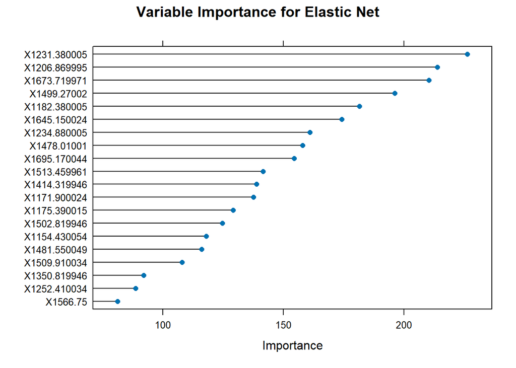

```r
# Calculate variable importance
importance <- varImp(fit_elastic_net_raw, scale = FALSE)

# Plot variable importance
plot(importance, top = 20, main = "Variable Importance for Elastic Net")
```

#### Coefficients vs. Lambda Path

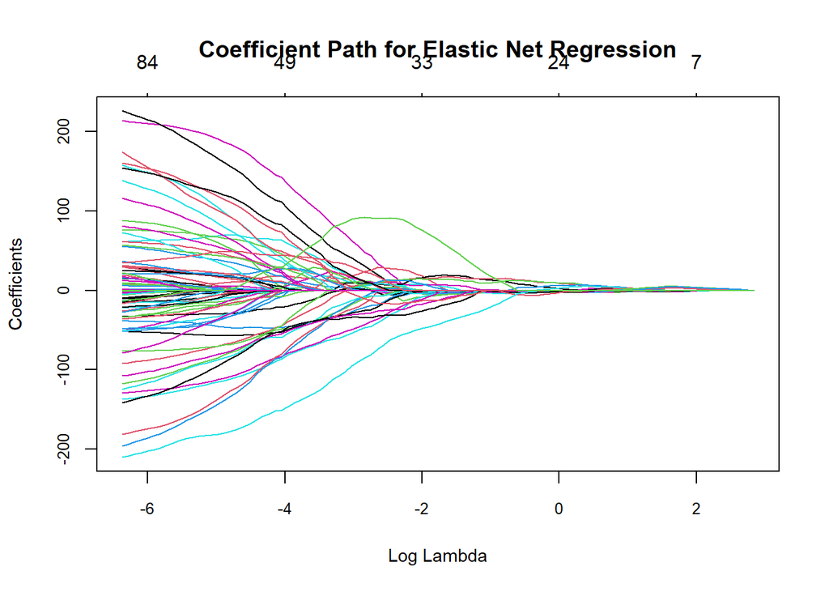

```r
# Extract the final glmnet model
fit_glmnet <- fit_elastic_net_raw$finalModel

# Plot coefficients vs. lambda
plot(
  fit_glmnet,
  xvar = "lambda",
  label = FALSE,
  cex.axis = 0.8,
  cex.lab = 0.9,
  cex.main = 0.3)
title(main = "Coefficient Path for Elastic Net Regression")
```

```r
# As lambda increases, coefficients shrink toward zero, highlighting the feature selection process
```

## Display CV Results in Tables

```r
kable(fit_elastic_net_raw$results)
```

| alpha | lambda | RMSE | Rsquared | MAE | RMSESD | RsquaredSD | MAESD |
| --- | --- | --- | --- | --- | --- | --- | --- |
| 0.0000000 | 0.001 | 18.248727 | 0.6020999 | 14.798617 | 1.0111878 | 0.0453001 | 0.8739045 |
| 0.0000000 | 0.012 | 18.248727 | 0.6020999 | 14.798617 | 1.0111878 | 0.0453001 | 0.8739045 |
| 0.0000000 | 0.023 | 18.248727 | 0.6020999 | 14.798617 | 1.0111878 | 0.0453001 | 0.8739045 |
| 0.0000000 | 0.034 | 18.248727 | 0.6020999 | 14.798617 | 1.0111878 | 0.0453001 | 0.8739045 |
| 0.0000000 | 0.045 | 18.248727 | 0.6020999 | 14.798617 | 1.0111878 | 0.0453001 | 0.8739045 |
| 0.0000000 | 0.056 | 18.248727 | 0.6020999 | 14.798617 | 1.0111878 | 0.0453001 | 0.8739045 |
| 0.0000000 | 0.067 | 18.248727 | 0.6020999 | 14.798617 | 1.0111878 | 0.0453001 | 0.8739045 |
| 0.0000000 | 0.078 | 18.248727 | 0.6020999 | 14.798617 | 1.0111878 | 0.0453001 | 0.8739045 |
| 0.0000000 | 0.089 | 18.248727 | 0.6020999 | 14.798617 | 1.0111878 | 0.0453001 | 0.8739045 |
| 0.0000000 | 0.100 | 18.248727 | 0.6020999 | 14.798617 | 1.0111878 | 0.0453001 | 0.8739045 |
| 0.1111111 | 0.001 | 10.114290 | 0.8822537 | 8.108417 | 0.7440899 | 0.0189820 | 0.6138568 |
| 0.1111111 | 0.012 | 10.135369 | 0.8817358 | 8.124840 | 0.7490310 | 0.0191587 | 0.6170247 |
| 0.1111111 | 0.023 | 11.755631 | 0.8388342 | 9.415741 | 0.8343244 | 0.0250234 | 0.6945933 |
| 0.1111111 | 0.034 | 12.598700 | 0.8139882 | 10.093976 | 0.8809106 | 0.0282590 | 0.7439050 |
| 0.1111111 | 0.045 | 13.160165 | 0.7965722 | 10.541367 | 0.9078957 | 0.0303472 | 0.7710009 |
| 0.1111111 | 0.056 | 13.586843 | 0.7828353 | 10.878367 | 0.9266310 | 0.0319294 | 0.7906749 |
| 0.1111111 | 0.067 | 13.926947 | 0.7715776 | 11.149838 | 0.9390690 | 0.0331268 | 0.8037390 |
| 0.1111111 | 0.078 | 14.207512 | 0.7620903 | 11.374968 | 0.9492867 | 0.0341169 | 0.8151133 |
| 0.1111111 | 0.089 | 14.440563 | 0.7540964 | 11.561456 | 0.9592184 | 0.0350087 | 0.8250299 |
| 0.1111111 | 0.100 | 14.648014 | 0.7468660 | 11.726380 | 0.9680299 | 0.0358168 | 0.8333310 |
| 0.2222222 | 0.001 | 8.298559 | 0.9214532 | 6.659288 | 0.6474692 | 0.0125058 | 0.5270127 |
| 0.2222222 | 0.012 | 9.927174 | 0.8866651 | 7.931964 | 0.7538864 | 0.0184184 | 0.6172872 |
| 0.2222222 | 0.023 | 11.596642 | 0.8433633 | 9.272245 | 0.8468107 | 0.0247865 | 0.7034160 |
| 0.2222222 | 0.034 | 12.523617 | 0.8164543 | 10.027338 | 0.8822459 | 0.0279087 | 0.7432281 |
| 0.2222222 | 0.045 | 13.163287 | 0.7965864 | 10.543836 | 0.9106721 | 0.0302952 | 0.7727573 |
| 0.2222222 | 0.056 | 13.637848 | 0.7812534 | 10.924063 | 0.9301830 | 0.0320392 | 0.7958603 |
| 0.2222222 | 0.067 | 14.017931 | 0.7685887 | 11.232040 | 0.9466699 | 0.0334797 | 0.8125101 |
| 0.2222222 | 0.078 | 14.322145 | 0.7582435 | 11.479051 | 0.9576878 | 0.0345455 | 0.8250051 |
| 0.2222222 | 0.089 | 14.580930 | 0.7492879 | 11.687070 | 0.9666338 | 0.0354685 | 0.8349776 |
| 0.2222222 | 0.100 | 14.802175 | 0.7415246 | 11.863936 | 0.9740695 | 0.0362747 | 0.8430915 |

[output cut: 70 more lines]

```r
# Select row for the optimal model
opt_row <- fit_elastic_net_raw$results %>%
  filter(lambda==fit_elastic_net_raw$bestTune$lambda &
           alpha == fit_elastic_net_raw$bestTune$alpha)

kable(opt_row)
```

| alpha | lambda | RMSE | Rsquared | MAE | RMSESD | RsquaredSD | MAESD |
| --- | --- | --- | --- | --- | --- | --- | --- |
| 0.7777778 | 0.001 | 6.164808 | 0.9551864 | 4.940827 | 0.7108137 | 0.0117428 | 0.5342367 |

## Test the model performance on test data

```r
#Predict on the test set
observed <- test_merged$y_test
predictions <- predict(fit_elastic_net_raw,newdata=test_merged)

# Generate predictions
results <- postResample(predictions, observed)

print(results)
```

```
     RMSE  Rsquared       MAE
7.9717642 0.9400364 6.7185417
```

```r
RMSEP = results[[1]]
R2 = results[[2]]
MAE = results[[3]]

cat('The RMSEP for the model on external validation is:', RMSEP,'\n')
```

```
The RMSEP for the model on external validation is: 7.971764
```

```r
cat('The R Squared value for the model is:', R2)
```

```
The R Squared value for the model is: 0.9400364
```

```r
# Calculate Residual Predictive Deviation to check model performance

RPD = sd(observed)/RMSEP

print(paste('The RPD values for the model is', round(RPD,2)))
```

```
[1] "The RPD values for the model is 3.66"
```

## Visualizations

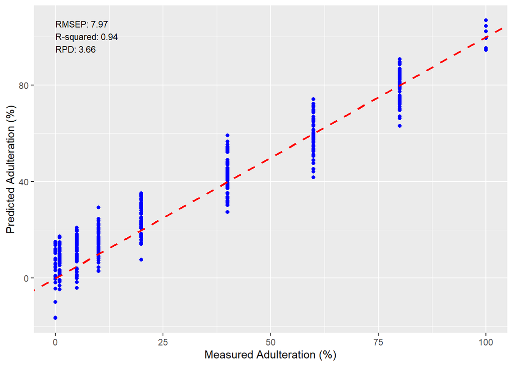

```r
# predicted vs observed line and scatter
# Create a data frame
results_df <- data.frame(observed=observed, predictions=predictions)

results_df %>%
  ggplot(aes(x = observed, y = predictions)) +
  geom_point(color = "blue") +
  geom_abline(slope = 1, intercept = 0, color = "red",
              linetype = "dashed", linewidth = 1) +
  labs( x = "Measured Adulteration (%)",
    y = "Predicted Adulteration (%)") +
  annotate("text",
    x = min(observed), y = max(predictions),
    label = paste("RMSEP:", round(RMSEP, 2),
      "\nR-squared:", round(R2, 3),
      "\nRPD:", round(RPD, 2)),
    hjust = 0, vjust = 1, size = 3, color = "black") +
  theme(
    axis.title = element_text(color = "black", size = 10),
    axis.text = element_text(color = "black"))+
  theme_gray()
```

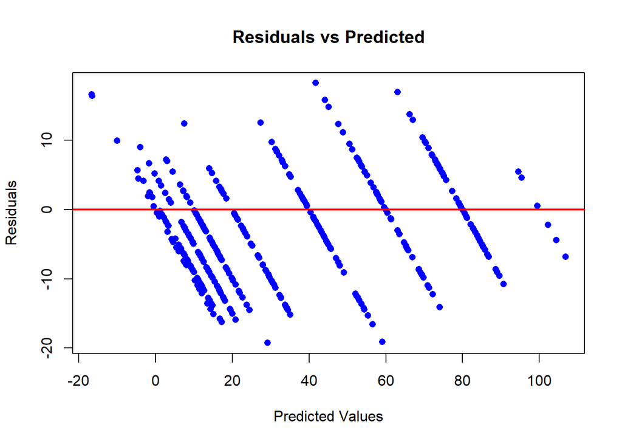

```r
# Check residuals

residuals <- observed - predictions

# Plot Residuals
plot(predictions, residuals,
     xlab = "Predicted Values",
     ylab = "Residuals",
     main = "Residuals vs Predicted",
     pch = 16, col = "blue")
abline(h = 0, col = "red", lwd = 2)
```

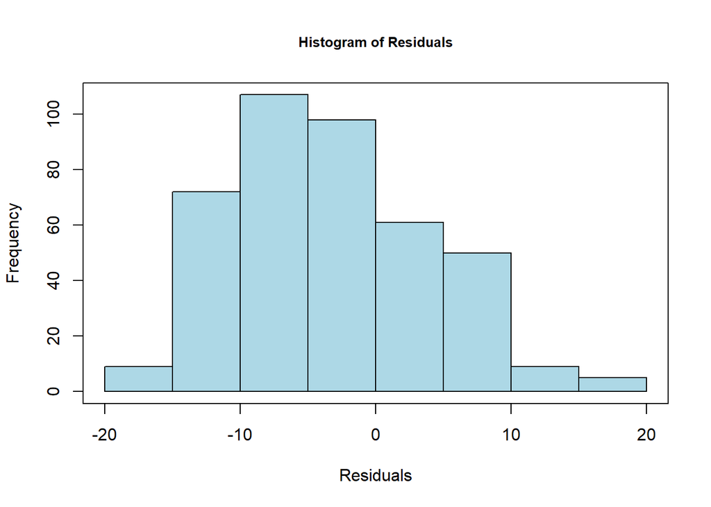

```r
hist(residuals,
     main = "Histogram of Residuals",
     xlab = "Residuals", cex.main = 0.8,
     col = "lightblue", border = "black"); box()
```